# CATEDisplays: Getting Started

## 3. Run main wrapper function:

### Option 1: Not combining trials

Here cateDisplay() will estimate a casual forest and assess treatment effect heterogeneity separately for each single trial.

```r
catesDisplay <- CATEDisplays::displayCATE(dfList,
                           outCol="outc",
                           txCol="tx",
                           covList= c("age", "race", "educ", "sex", "ASIalc"),
                           blpredList=NULL,
                           combine=F,
                           verbose=T,
                           ci=0.95, nTrees=10000, seedN=7203)
```

[1] “– 95% CI for the ATE: -0.043064 +/- 0.192844” [1] “Estimate: 0.455 || Pr(>t): 0.252” [1] “The `differential.forest.prediction` coefficient is not significantly greater than 0: we cannot reject the null of no heterogeneity.” [1] “– 95% CI for the ATE: -0.150348 +/- 0.833868” [1] “Estimate: -13.645 || Pr(>t): 1” [1] “The `differential.forest.prediction` coefficient is not significantly greater than 0: we cannot reject the null of no heterogeneity.” [1] “– 95% CI for the ATE: 0.017555 +/- 0.155471” [1] “Estimate: -1.22 || Pr(>t): 0.89” [1] “The `differential.forest.prediction` coefficient is not significantly greater than 0: we cannot reject the null of no heterogeneity.” [1] “– 95% CI for the ATE: 0.092579 +/- 0.157179” [1] “Estimate: -0.407 || Pr(>t): 0.686” [1] “The `differential.forest.prediction` coefficient is not significantly greater than 0: we cannot reject the null of no heterogeneity.” [1] “– 95% CI for the ATE: -0.148128 +/- 0.252293” [1] “Estimate: 0.694 || Pr(>t): 0.215” [1] “The `differential.forest.prediction` coefficient is not significantly greater than 0: we cannot reject the null of no heterogeneity.”

Inspect output elements for a given study (say, study #2):

```r
studyNum = 2
cateOutput <- catesDisplay$cateOutput[[studyNum]]
```

ATE:

```r
cateOutput$ATE
```

```
#>   estimate    std.err
#> -0.1503478  0.4254509
```

HTE test: “The p-value of the ‘differential.forest.prediction’ coefficient also acts as an omnibus test for the presence of heterogeneity: If the coefficient is significantly greater than 0, then we can reject the null of no heterogeneity.” (see [grf package documentation](https://search.r-project.org/CRAN/refmans/grf/html/test_calibration.html))

```r
cateOutput$testHTE
```

```
#>
#> Best linear fit using forest predictions (on held-out data)
#> as well as the mean forest prediction as regressors, along
#> with one-sided heteroskedasticity-robust (HC3) SEs:
#>
#>                                 Estimate Std. Error t value Pr(>t)
#> mean.forest.prediction           0.96809    1.51521  0.6389  0.263
#> differential.forest.prediction -13.64499    1.72046 -7.9310  1.000
```

Augmented dataset:

```r
head(cateOutput$cateDF, 5)
```

```
#>   indID     race         educ    sex     tau.hat lowerinterval upperinterval
#> 1     1    White Less than HS Female -0.12614034    -0.7947899     0.5425092
#> 2     2 Hispanic      College   Male -0.09289544    -0.7615450     0.5757541
#> 3     3    Black Less than HS   Male -0.07333199    -0.7419816     0.5953176
#> 4     4    Black           HS Female -0.09727048    -0.7659200     0.5713791
#> 5     5    White      College Female -0.09020107    -0.7588506     0.5784485
#>           Y tx (Intercept)   age raceBlack raceHispanic raceOther raceWhite
#> 1 0.1792569  0           1 49.85         0            0         0         1
#> 2 1.1362920  0           1 23.54         0            1         0         0
#> 3 0.1340899  1           1 20.00         1            0         0         0
#> 4 1.3999692  0           1 42.69         1            0         0         0
#> 5 1.0558012  0           1 32.85         0            0         0         1
#>   educGraduate educHS educLess than HS sexMale      ASIalc
#> 1            0      0                1       0 -0.25979911
#> 2            0      0                0       1 -0.08199004
#> 3            0      0                1       1  0.01534669
#> 4            0      1                0       0 -0.05386798
#> 5            0      0                0       0 -0.23791487
```

Best linear projection: “Let tau(Xi) = E[Y(1) - Y(0) | X = Xi] be the CATE, and Ai be a vector of user-provided covariates. This function provides a (doubly robust) fit to the linear model tau(Xi) ~ beta_0 + Ai * beta.” (see [grf package documentation](https://grf-labs.github.io/grf/reference/best_linear_projection.html))

```r
cateOutput$BLP
```

```
#>
#> Best linear projection of the conditional average treatment effect.
#> Confidence intervals are cluster- and heteroskedasticity-robust (HC3):
#>
#>                   Estimate Std. Error t value Pr(>|t|)
#> (Intercept)      -0.873052   2.556922 -0.3414  0.73460
#> age              -0.031294   0.054475 -0.5745  0.56896
#> raceBlack         1.979802   1.741435  1.1369  0.26253
#> raceHispanic      2.546952   1.782463  1.4289  0.16100
#> raceOther         0.806149   1.903530  0.4235  0.67426
#> raceWhite         2.581042   1.644927  1.5691  0.12471
#> educGraduate     -1.155933   1.290425 -0.8958  0.37587
#> educHS            2.622617   1.205433  2.1757  0.03570 *
#> educLess.than.HS  1.238606   1.026346  1.2068  0.23477
#> sexMale          -2.278485   1.076763 -2.1161  0.04078 *
#> ASIalc           -0.628330   1.782144 -0.3526  0.72631
#> ---
#> Signif. codes:  0 '***' 0.001 '**' 0.01 '*' 0.05 '.' 0.1 ' ' 1
```

CATE visualizations (all studies):

1. Overall CATE estimates:

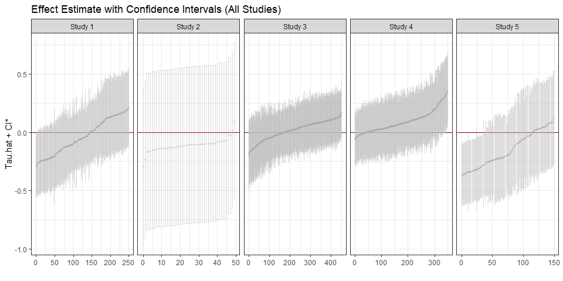

```r
catesDisplay$vizTauHat
```

2. CATE estimates by subgroup and study:

```r
catesDisplay$vizSubgroupCATE
```

[[1]]

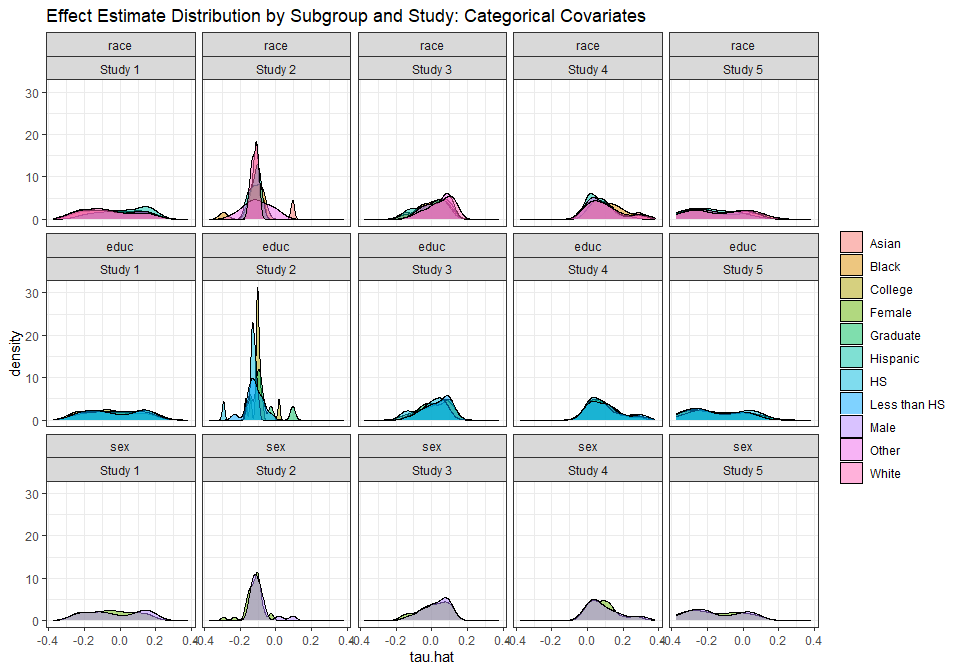

[[2]]

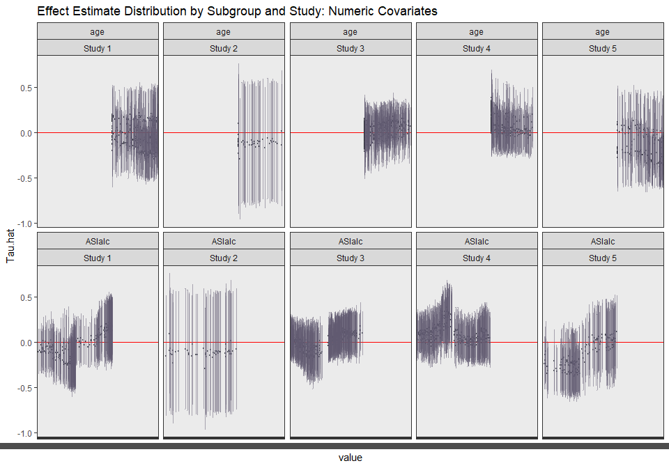

3. Best linear projection:

```r
catesDisplay$vizBLP
```

NULL

### Option 2: Combining trials

Here cateDisplay() will first combine the data from all trials, and then estimate the CATE casual forest (including a study indicator) and assess treatment effect heterogeneity. As noted above, although technically not required, when merging data coming from multiple trials, it is highly recommended that the treatment and outcome have a similar meaning across studies.

```r
catesDisplayCombined <- CATEDisplays::displayCATE(dfList,
                                  outCol="outc",
                                  txCol="tx",
                                  covList= c("age", "race", "educ",
                                             "sex", "ASIalc"),
                                  blpredList=NULL,
                                  combine=T,
                                  ci=0.95,
                                  verbose=T,
                                  nTrees=10000,
                                  seedN=7203)
```

[1] “– 95% CI for the ATE: -0.00198 +/- 0.087023” [1] “Estimate: 0.793 || Pr(>t): 0.015” [1] “The `differential.forest.prediction` coefficient is significantly greater than 0: we can reject the null of no heterogeneity.”

Again, we can inspect all the elements of the main output, and save resulting visuals.

```r
cateOutput <- catesDisplayCombined$cateOutput
```

ATE:

```r
cateOutput$ATE
```

```
#>     estimate      std.err
#> -0.001980181  0.044400108
```

HTE:

```r
cateOutput$testHTE
```

```
#>
#> Best linear fit using forest predictions (on held-out data)
#> as well as the mean forest prediction as regressors, along
#> with one-sided heteroskedasticity-robust (HC3) SEs:
#>
#>                                Estimate Std. Error t value  Pr(>t)
#> mean.forest.prediction         -0.64415   26.86173 -0.0240 0.50956
#> differential.forest.prediction  0.79252    0.36677  2.1608 0.01545 *
#> ---
#> Signif. codes:  0 '***' 0.001 '**' 0.01 '*' 0.05 '.' 0.1 ' ' 1
```

Augmented dataset:

```r
head(cateOutput$cateDF, 5)
```

```
#>   indID   study  race         educ    sex     tau.hat lowerinterval
#> 1     1 Study 1 Black     Graduate Female -0.12005481    -0.3738017
#> 2     2 Study 1 White      College   Male  0.09906570    -0.1426328
#> 3     3 Study 1 Other Less than HS Female -0.02810620    -0.2458173
#> 4     4 Study 1 Other      College   Male -0.35230686    -0.6127435
#> 5     5 Study 1 Other      College   Male  0.03542723    -0.2065744
#>   upperinterval          Y tx (Intercept) studyStudy2 studyStudy3 studyStudy4
#> 1    0.13369208 -1.0102844  0           1           0           0           0
#> 2    0.34076417  1.6087325  1           1           0           0           0
#> 3    0.18960493 -0.1343341  0           1           0           0           0
#> 4   -0.09187018  1.0284937  0           1           0           0           0
#> 5    0.27742882  0.7485043  1           1           0           0           0
#>   studyStudy5   age raceBlack raceHispanic raceOther raceWhite educGraduate
#> 1           0 30.53         1            0         0         0            1
#> 2           0 44.43         0            0         0         1            0
#> 3           0 25.47         0            0         1         0            0
#> 4           0 60.45         0            0         1         0            0
#> 5           0 22.99         0            0         1         0            0
#>   educHS educLess than HS sexMale     ASIalc
#> 1      0                0       0 -0.8420867
#> 2      0                0       1  1.2679759
#> 3      0                1       0 -1.3480613
#> 4      0                0       1 -0.2771001
#> 5      0                0       1 -1.1115444
```

Results from the best linear projection:

```r
cateOutput$BLP
```

```
#>
#> Best linear projection of the conditional average treatment effect.
#> Confidence intervals are cluster- and heteroskedasticity-robust (HC3):
#>
#>                    Estimate Std. Error t value Pr(>|t|)
#> (Intercept)       0.2061758  0.2320714  0.8884  0.37449
#> studyStudy2      -0.1763687  0.3041275 -0.5799  0.56208
#> studyStudy3      -0.0277516  0.1327912 -0.2090  0.83449
#> studyStudy4       0.0094933  0.1398609  0.0679  0.94589
#> studyStudy5      -0.0943147  0.1563889 -0.6031  0.54657
#> age              -0.0084535  0.0043462 -1.9450  0.05200 .
#> raceBlack         0.2564321  0.1540996  1.6641  0.09635 .
#> raceHispanic     -0.0189926  0.1463134 -0.1298  0.89674
#> raceOther         0.1501364  0.1464557  1.0251  0.30550
#> raceWhite         0.2627560  0.1473686  1.7830  0.07483 .
#> educGraduate     -0.1007717  0.1315153 -0.7662  0.44368
#> educHS           -0.1017536  0.1197680 -0.8496  0.39572
#> educLess.than.HS  0.0811835  0.1166879  0.6957  0.48673
#> sexMale          -0.0242701  0.0898795 -0.2700  0.78718
#> ASIalc            0.3309651  0.1329521  2.4894  0.01293 *
#> ---
#> Signif. codes:  0 '***' 0.001 '**' 0.01 '*' 0.05 '.' 0.1 ' ' 1
```

See visuals (combined studies):

CATE visualizations (all studies):

1. Overall CATE estimates:

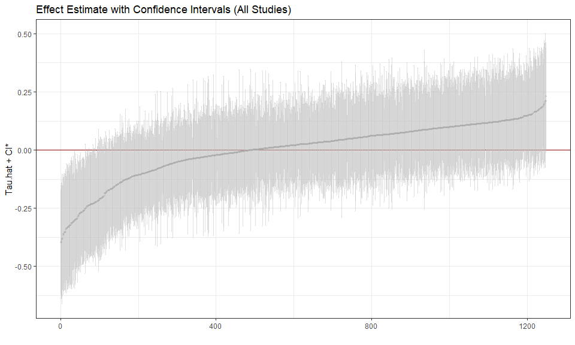

```r
catesDisplayCombined$vizTauHat
```

2. CATE estimates by subgroup:

```r
catesDisplayCombined$vizSubgroupCATE
```

[[1]]

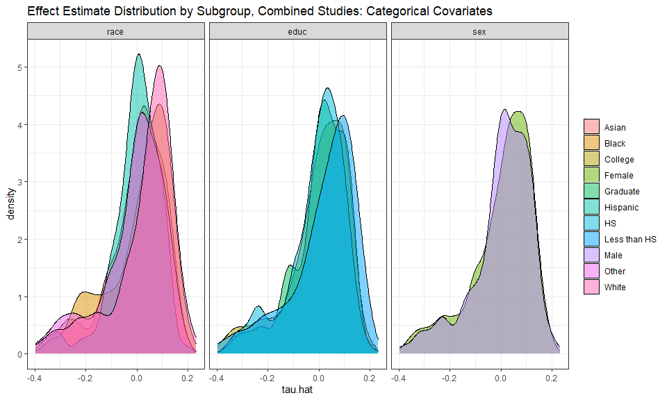

[[2]]

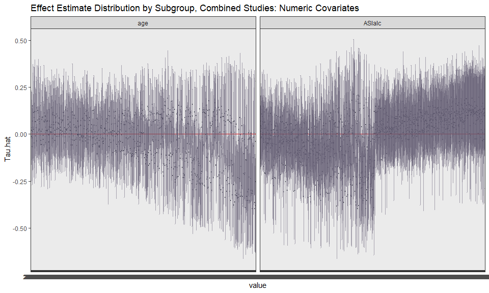

3. BLP (here we are opting for using the vizBLP function directly over the getCATE output object, instead):

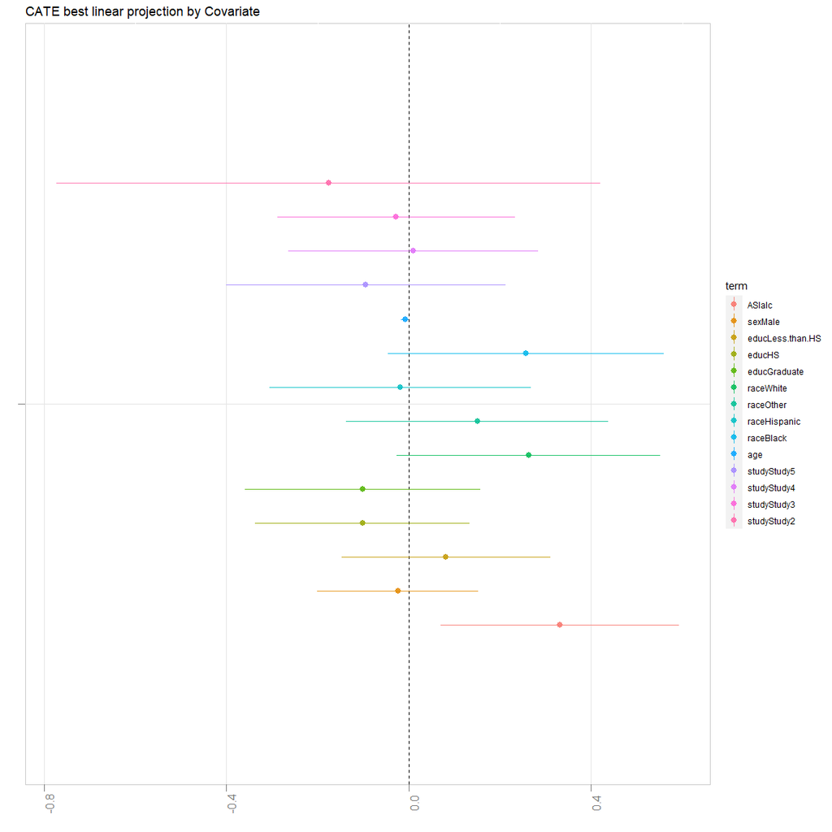

```r
vizBLP(cateOutput, combine=T)
```